# STAT380- Homework 7

Vince Trost- 958112459

4/17/2017

# 1. Temperature Data from State College and Ann Arbor

**Building upon previous homework assignments:**

Consider this data set on temperatures: http://sites.stat.psu.edu/~mharan/380/data/tempGHCN/SCEAnnArborTwoStations.csv

```r
temps <- read.csv("http://sites.stat.psu.edu/~mharan/380/data/tempGHCN/SCEAnnArborTwoStations.csv")
head(temps)
```

```
##             STATION        STATION_NAME     DATE TMAX Measurement.Flag
## 1 GHCND:USC00368449 STATE COLLEGE PA US 18930201   33               NA
## 2 GHCND:USC00368449 STATE COLLEGE PA US 18930202   34               NA
## 3 GHCND:USC00368449 STATE COLLEGE PA US 18930203   44               NA
## 4 GHCND:USC00368449 STATE COLLEGE PA US 18930204   32               NA
## 5 GHCND:USC00368449 STATE COLLEGE PA US 18930205   21               NA
## 6 GHCND:USC00368449 STATE COLLEGE PA US 18930206   43               NA
##   Quality.Flag Source.Flag Time.of.Observation TMIN Measurement.Flag.1
## 1                        6                9999   29                 NA
## 2                        6                9999   21                 NA
## 3                        6                9999   21                 NA
## 4                        6                9999    5                 NA
## 5                        6                9999    3                 NA
## 6                        6                9999   20                 NA
##   Quality.Flag.1 Source.Flag.1 Time.of.Observation.1  TOBS
## 1                            6                  9999 -9999
## 2                            6                  9999 -9999
## 3                            6                  9999 -9999
## 4                            6                  9999 -9999
## 5                            6                  9999 -9999
## 6                            6                  9999 -9999
##   Measurement.Flag.2 Quality.Flag.2 Source.Flag.2 Time.of.Observation.2
## 1                 NA                                               9999
## 2                 NA                                               9999
## 3                 NA                                               9999
## 4                 NA                                               9999
## 5                 NA                                               9999
## 6                 NA                                               9999
```

This is similar to but not exactly the same as, the data sets you have worked on before. Look through the data set carefully to make sure you understand it well before writing code for it.

For this homework, you will need to calculate the following information: for State College and Ann Arbor, the mean monthly average temperatures and variability of the average monthly temperatures for each of 12 months (this is similar to your previous homework). That is, you should report the following:

1(a) Table 1: with two columns corresponding to location (State College and Ann Arbor) and 12 rows, with each row corresponding to the month of the year.

1(b) Table 2: just like Table 1, except this time with standard deviations of monthly average temperatures (instead of mean monthly averages).

1(c) 1 or 2 figures that summarize the above information. The figures should be easy to read; please follow the rules we discussed before regarding figures/plots.

1(d) Please summarize in just a few sentences (write your points in a numbered list) the main things you observe from the above summary. For instance, how do State College and Ann Arbor temperatures compare?

(If you are curious, you can also do some comparisons between the beginning of the data up to 1960 versus 1960 until present day data just to see if things have changed over time. But this is not required for this homework!)

# Number 1- Start

So if I want to see the monthly average temperatures and their variability for both State College and Ann Arbor, first I need to do some data wrangling.  
Let’s get the monthly average temps for Ann Arbor and State College.

```r
### DATA CLEANING ###

#Step 1: turning 9999 into NAs & dropping them
temps$TOBS[temps$TOBS==-9999]=NA
temps <- temps %>%
  filter(!is.na(temps$TOBS))

#Step 2: subset the data by getting only relevant columns
keeps <- c("STATION_NAME","TOBS", "DATE")
temps2 <- temps %>%
  select(one_of(keeps))

#Step 3: date formatting with lubridate
temps2$DATE <- ymd(temps2$DATE)

#Step 4: separate SC and AA data
#parse the strings of the levels in STATION_NAME
#work with it as a string
temps2$STATION_NAME <- as.character(temps2$STATION_NAME)
#get rid of everything after the first space- will be left with STATE and ANN
temps2$STATION_NAME <- gsub(" [A-z]*", "", temps2$STATION_NAME)
#really annoying case where there's ANN1- use regex to make it ANN
temps2$STATION_NAME <- gsub("[[:digit:]]", "", temps2$STATION_NAME)
#back to factor- ANN and STATE
temps2$STATION_NAME <- as.factor(temps2$STATION_NAME)
#separate ANN and STATE into different data frames for ease of use
mich <- temps2 %>%
  filter(STATION_NAME == "ANN")
state <- temps2 %>%
  filter(STATION_NAME == "STATE")

#Step 5: get the monthly averages for the two locations and their SD's
stateAvgs <- state %>%
  group_by(month = month(DATE)) %>%
  summarise(avgTemp = mean(TOBS))
head(stateAvgs)
```

```
## # A tibble: 6 × 2
##   month  avgTemp
##   <dbl>    <dbl>
## 1     1 25.29032
## 2     2 26.18733
## 3     3 34.24526
## 4     4 45.22946
## 5     5 56.11827
## 6     6 64.31529
```

```r
michAvgs <- mich %>%
  group_by(month = month(DATE)) %>%
  summarise(avgTemp = mean(TOBS))
head(michAvgs)
```

```
## # A tibble: 6 × 2
##   month  avgTemp
##   <dbl>    <dbl>
## 1     1 25.56743
## 2     2 28.40963
## 3     3 38.35803
## 4     4 51.84313
## 5     5 64.20546
## 6     6 73.60056
```

```r
stateSDs <- state %>%
  group_by(month = month(DATE)) %>%
  summarise(sdTemp = sd(TOBS))
head(stateSDs)
```

```
## # A tibble: 6 × 2
##   month    sdTemp
##   <dbl>     <dbl>
## 1     1 11.642637
## 2     2 11.383721
## 3     3 11.230945
## 4     4 10.394007
## 5     5  8.980002
## 6     6  7.349370
```

```r
michSDs <- mich %>%
  group_by(month = month(DATE)) %>%
  summarise(sdTemp = sd(TOBS))
head(michSDs)
```

```
## # A tibble: 6 × 2
##   month    sdTemp
##   <dbl>     <dbl>
## 1     1 10.534293
## 2     2 10.276701
## 3     3 11.807537
## 4     4 11.971887
## 5     5 10.824626
## 6     6  9.206893
```

```r
#Step 6: join the averages with their respective standard deviations, put them into one data frame for easy plotting
PSU <- full_join(stateAvgs, stateSDs, by = "month")
PSU <- PSU %>% mutate(location = "PSU")
UMICH <- full_join(michAvgs, michSDs, by = "month")
UMICH <- UMICH %>% mutate(location = "UMICH")
BOTH <- rbind(PSU, UMICH)
```

Now we’ve got the data how we want it. Let’s make the figure. My goal was to make the most informative single figure possible.

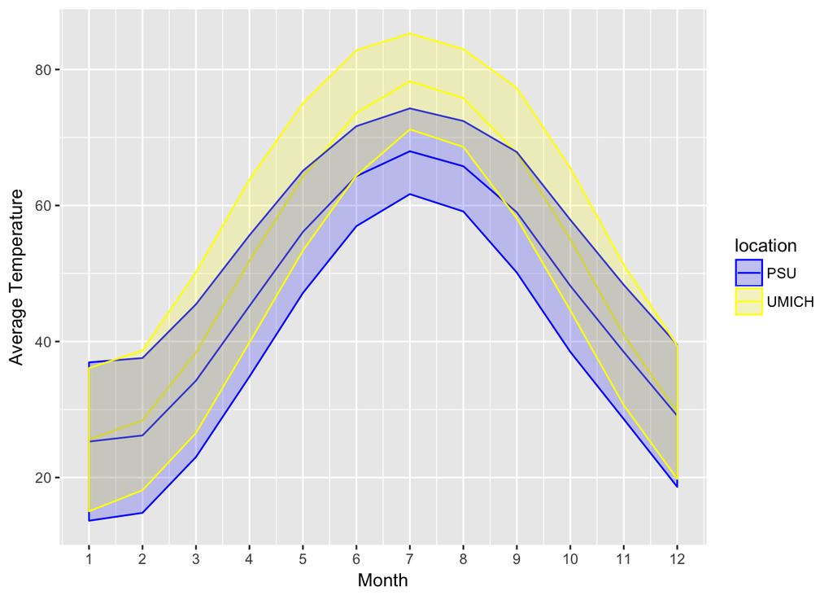

```r
ggplot(BOTH, aes(x=month, y=avgTemp, color = location))+
  geom_line()+geom_ribbon(aes(ymin=(avgTemp-sdTemp), ymax=(avgTemp+sdTemp), fill = location), alpha = 0.2)+
  scale_color_manual(values=c("blue", "yellow"))+
  scale_fill_manual(values = c("blue", "yellow"))+
  scale_x_continuous(breaks = 1:12)+
  xlab("Month")+
  ylab("Average Temperature")
```

# 2. Email spam filtering

**Preliminary exercise**

As we discussed in class, we can use a naive Bayes classifier as a method to do spam filtering with emails. One approach to this is to extract from each email the main words from the text of the emails. Once we have translated each email into a “bag of words”, we can use train our classifier on spam and non-spam (“ham”) emails. This training allows us to then classify any new email as either spam or ham.

Working through all the steps at once would be a major challenge. Hence, in this homework you will just do a small subset of the list of tasks necessary to create a spam filter. Please take a look at at least 3 examples each of spam and ham email messages in the folders “spam” and “easy_ham” in the directory: http://sites.stat.psu.edu/~mharan/380/data/spam/ The folders include over a thousand emails each, each one stored in a separate file with long names like 00001.7848dde101aa985090474a91ec93fcf0 and 00002.d94f1b97e48ed3b553b3508d116e6a09

If you like, you can simply download the zip file onto your computer, unzip the file (this will create directories/folders on your computer) and work with the files from your computer.

2(a) Write an R function that, given a filename for an email message, removes the header from the email messages. The header is the part that appears at the beginning of all the emails. For instance, you could consider deleting everything up to Content-Transfer-Encoding: You could also delete the words that immediately follow Content-Transfer-Encoding:

The above idea is just an example. For instance, in the ham folders, the line Content-Transfer-Encoding does not appear so perhaps you will need to use some other patterns to remove the headers.

After your code operates on the file, it should return a string that contains the entire email but without the header. You will need to submit your code as well as the result of the application of your code to the email 00001.7848dde101aa985090474a91ec93fcf0 in the spam folder. Note that you should test the code on many emails to make sure it works well.

2(b) Write an R function that, given the name of the file, will look through the email and figure out whether it has html code in it or not. Look through the emails to figure out what html code looks likej it has Hence the function should just return either TRUE (html found) or FALSE (html not found).

# Number 2- Start

Load in the message.

```r
em1 <- readLines("00001.7848dde101aa985090474a91ec93fcf0")
byeHeader <- function(email){
  for(line in 1:length(email)){
    if(grepl("Content-Transfer-Encoding:", email[line]))
      return(email[line+1:length(email)])
    if(grepl("Subject:", email[line]))
      return(email[line:length(email)])
  }
}
em2 <- byeHeader(em1)
em2
```

```
##   [1] "Subject: Life Insurance - Why Pay More?"
##   [2] "Date: Wed, 21 Aug 2002 20:31:57 -1600"
##   [3] "MIME-Version: 1.0"
##   [4] "Message-ID: <0103c1042001882DD_IT7@dd_it7>"
##   [5] "Content-Type: text/html; charset=\"iso-8859-1\""
##   [6] "Content-Transfer-Encoding: quoted-printable"
##   [7] ""
##   [8] "<!DOCTYPE HTML PUBLIC \"-//W3C//DTD HTML 4.0 Transitional//EN\">"
##   [9] "<HTML><HEAD>"
##  [10] "<META content=3D\"text/html; charset=3Dwindows-1252\" http-equiv=3DContent-T="
##  [11] "ype>"
##  [12] "<META content=3D\"MSHTML 5.00.2314.1000\" name=3DGENERATOR></HEAD>"
##  [13] "<BODY><!-- Inserted by Calypso -->"
##  [14] "<TABLE border=3D0 cellPadding=3D0 cellSpacing=3D2 id=3D_CalyPrintHeader_ r="
##  [15] "ules=3Dnone "
```

[output cut: 93 more lines]

```r
html <- function(file){
  bool <- FALSE
  lines <- readLines(file)
  for(line in 1:length(lines)){
    if(grepl("<HTML>", lines[line]) || grepl("</HTML>", lines[line])){
      bool <- TRUE
      break
    }
  }
  return(bool)
}
fname <- "00001.7848dde101aa985090474a91ec93fcf0"
html(fname)
```

```
## [1] TRUE
```

My function successfully identifies html code in the emails.